# Assignment_6

Ritik Kumar

2024-11-16

## Importing the dataset

```r
library(forecast)
```

```r
library(ggplot2)
library(readxl)
library(UsingR)
#Import the dataset
data<- read_excel("C:/Users/malho/Downloads/TotalQuestions_Stack_Overflow.xlsx")
print(head(data))
```

```
## # A tibble: 6 × 21
##   Month  `C++`  `C#` TypeScript   PHP Swift  Ruby    Go   SQL Kotlin Scala Shell
##   <chr>  <dbl> <dbl>      <dbl> <dbl> <dbl> <dbl> <dbl> <dbl>  <dbl> <dbl> <dbl>
## 1 2008-…   755  1639          0   474     0   286     0   503      0     6    65
## 2 2008-…   734  1729          0   499     0   157     0   413      0     5    51
## 3 2008-…   630  1594          0   476     0   159     0   424      0     3    51
## 4 2009-…   848  2374          0   628     1   205     0   585      0    12    47
## 5 2009-…   841  2597          0   757     1   286     0   668      0    12    75
## 6 2009-…  1046  3155          0   895     1   329     0   658      0    17    85
## # ℹ 9 more variables: C <dbl>, HTML <dbl>, `Objective-C` <dbl>, Perl <dbl>,
## #   Matlab <dbl>, R <dbl>, Python <dbl>, Java <dbl>, Javascript <dbl>
```

## 1. Find an independent variable to predict your time-series (2 points)

- Dependent Variable: Let’s predict the number of questions related to Python.So,we are taking Python as the dependent variable.
- Independent Variables: Other languages or technologies like Java, JavaScript, and C++ might influence Python-related questions.Therefore, we are taking Java as independent variable to predict python related questions.
- The connection between Java with Python questions is not always direct but may reflect:
- Shifts in developer preferences.
- Complementary or competitive usage patterns.
- Shared communities or problem domains.

## 2. Perform regression (2 Points)

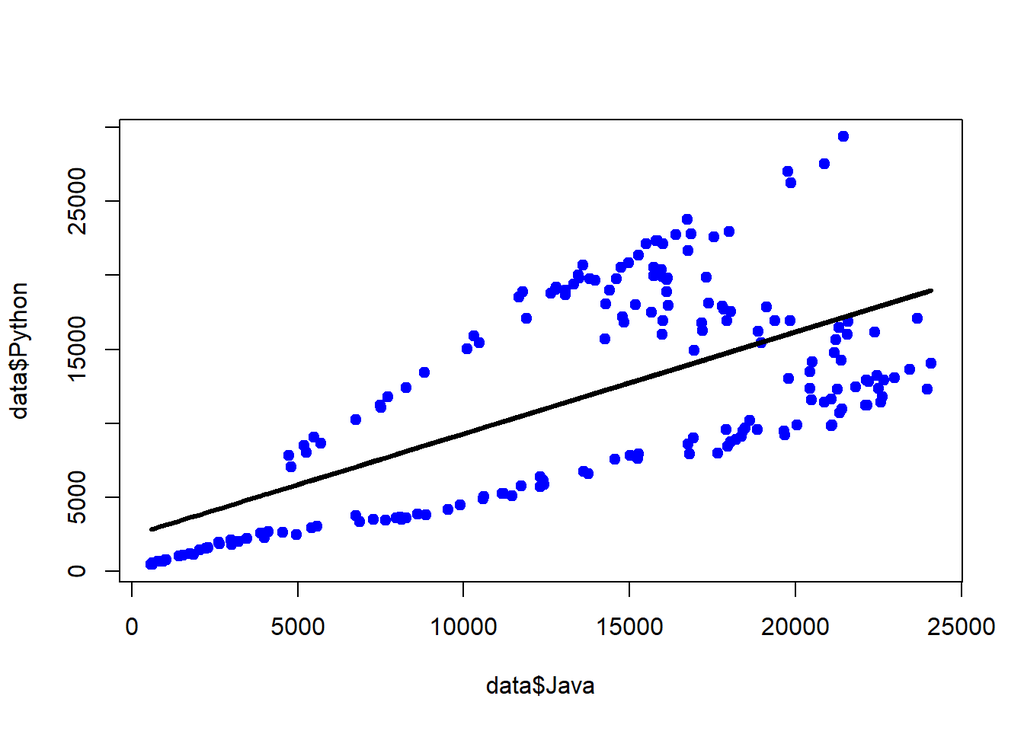

```r
## Create a Scatter Plot
plot(data$Java, data$Python,pch=19,col="blue")

## Conduct a linear Model Regression
lm1 <- lm(data$Python ~ data$Java)

## Add Regression Line to the scatter plot
lines(data$Java, lm1$fitted, col="black",lwd=3)
```

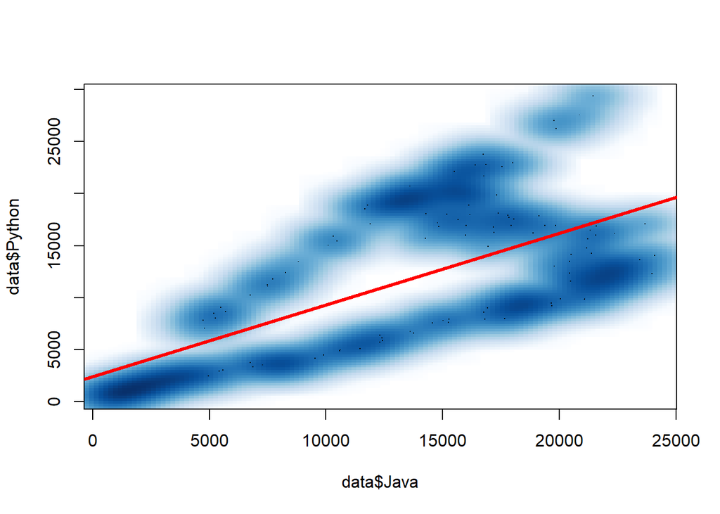

```r
## Visualize
smoothScatter(data$Java,data$Python)
abline(lm1,col="red",lwd=3)
```

## 3. Perform Model Acceptance Steps and show the interpretation of the model output (3 Points)

```r
summary(lm1)
```

```
##
## Call:
## lm(formula = data$Python ~ data$Java)
##
## Residuals:
##    Min     1Q Median     3Q    Max
##  -7105  -4828  -2369   4970  12192
##
## Coefficients:
##              Estimate Std. Error t value Pr(>|t|)
## (Intercept) 2.408e+03  9.162e+02   2.628  0.00932 **
## data$Java   6.891e-01  6.047e-02  11.395  < 2e-16 ***
## ---
## Signif. codes:  0 '***' 0.001 '**' 0.01 '*' 0.05 '.' 0.1 ' ' 1
##
## Residual standard error: 5417 on 183 degrees of freedom
## Multiple R-squared:  0.415,  Adjusted R-squared:  0.4119
## F-statistic: 129.8 on 1 and 183 DF,  p-value: < 2.2e-16
```

## Interpretation

- Model acceptance checks whether your regression model is statistically valid and interprets its results.
- p-value < 2.2e-16(a very small value close to zero) of java means the result is statistically significant, and the variable or model has a meaningful relationship with the dependent variable such as Python.
- The triple asterisks (***) in summary indicate that the p-value is below the default significance threshold of α =0.001, meaning the result is highly significant.
- Yes, data$Java is statistically significant, as the p-value (< 2e-16) is much smaller than α=0.05. This suggests that Java has a strong, meaningful relationship with the dependent variable Python in the regression model.

## 4. Perform Residual Analysis and explain the insights (3 Points)

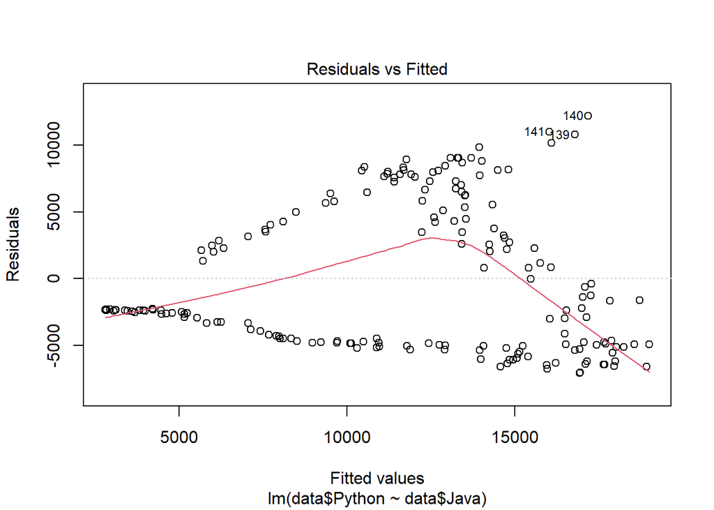

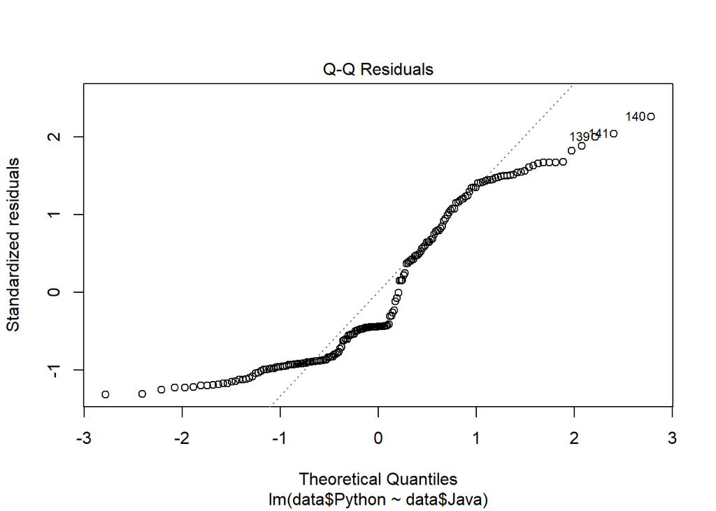

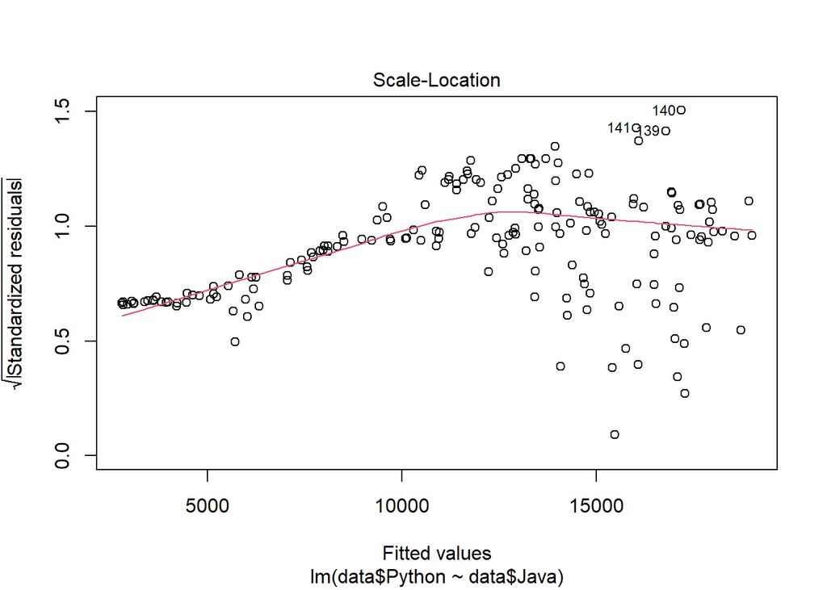

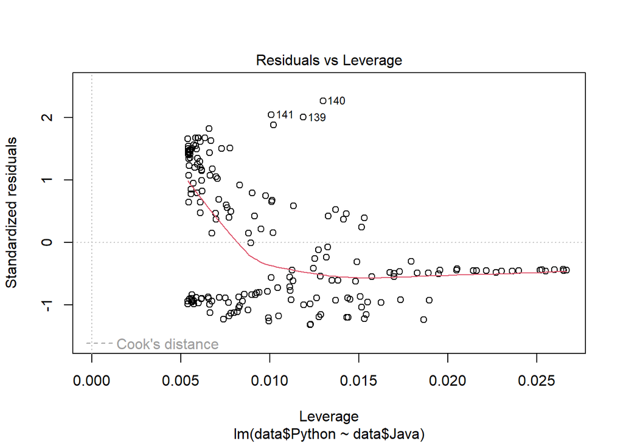

```r
# Residual Analysis
# 1. Plot gives multiple graphs for regression analysis
plot(lm1)
```

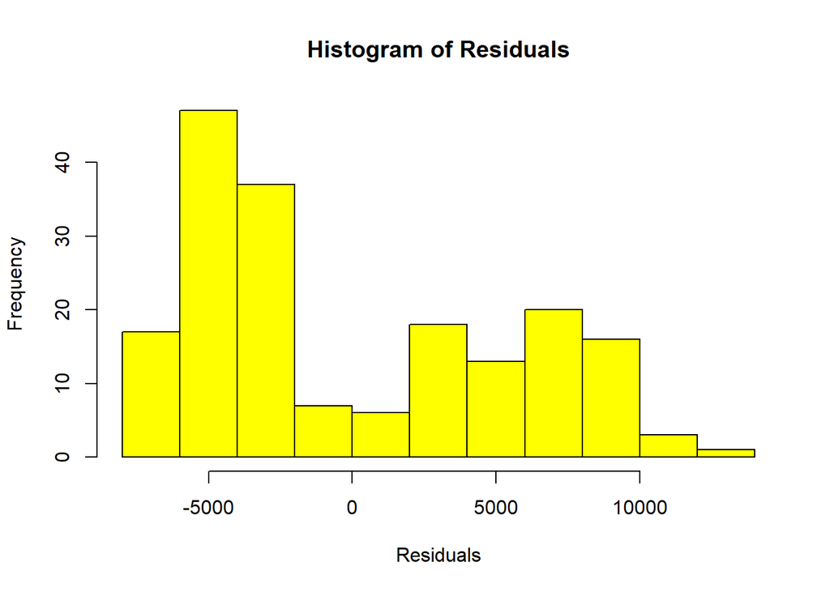

```r
# 2. Histogram of residuals
hist(residuals(lm1), main="Histogram of Residuals", xlab="Residuals", col="yellow")
```

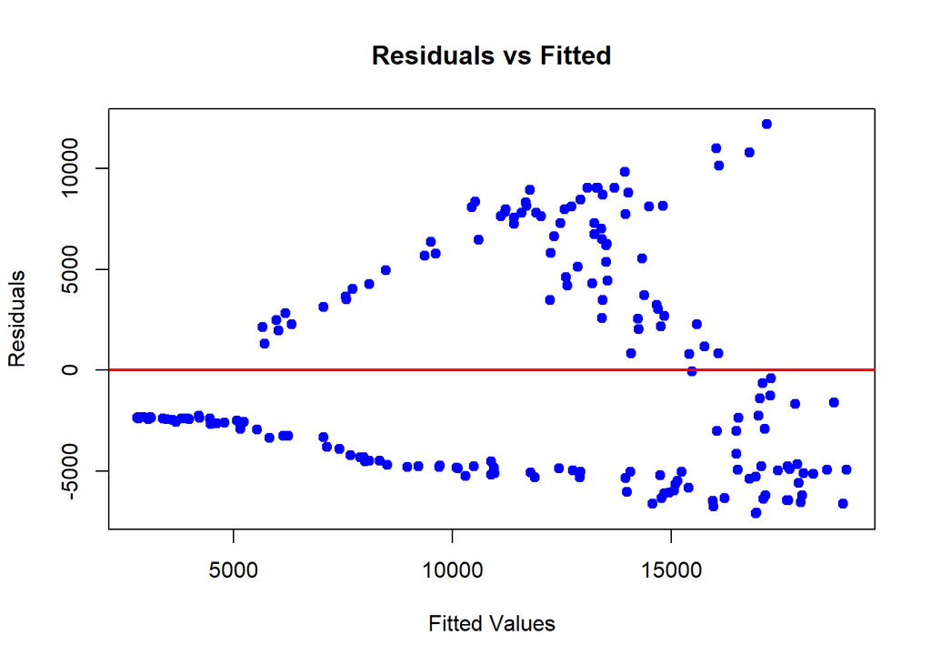

```r
# 3. Residuals vs Fitted plot to check homoscedasticity
plot(lm1$fitted.values, residuals(lm1), main="Residuals vs Fitted",
     xlab="Fitted Values", ylab="Residuals", pch=19, col="blue")
abline(h=0, col="red", lwd=2)
```

## Insights

- The command plot(lm1) generates several diagnostic plots that help assess the validity of the linear regression model (lm1).
- Histogram provides a visual representation of the distribution of residuals.So,it suggests residuals are not normally distributed.
- Residuals vs Fitted plot shows a pattern with increasing variance (fan shape), indicating heteroscedasticity, which violates the assumption of constant variance in linear regression. This suggests the need for transformations (e.g., log or square root) or alternative modeling techniques to address the issue.
- The straight red line in the Residuals vs Fitted plot represents the zero residual line. It indicates where residuals would lie if the model’s predictions were perfect (i.e., no difference between observed and predicted values).
- Also, It acts as a reference line to assess how the residuals are distributed around zero.